# afi_svc_clasificacion_digits_2022

## Recommendations in notebook writing

Notebooks are a great tool for data and model exploration. But in that process a lot of Python garbage can get into them as a consequence of the trial and error process.

But once these tasks are done and one arrives to final ideas and insights on the problem under study, the notebook should be **thoroughly cleaned** and the notebook should **concentrate on the insights and conclussions** without, of course, throwing away the good work done.

Below there are a few guidelines about this.

- Put the useful bits of your code as functions on a **Python module** (plus script, if needed) that is imported at the notebook's beginning.
- Of course that module should be **properly documented** and **formatted** (try to learn about PEP 8 if you are going to write a lot of Python).
- Leave in the notebook **as little code as possible**, ideally one- or two-line cells calling a function, plotting results or so on.
- **Avoid boilerplate code**. If needed, put it in a module.
- Put on the notebook some way to **hide/display the code** (as shown below).
- The displayed information **should be just that, informative**. So forget about large tables, long output cells, dataframe or array displays and so on.
- Emphasize **insights and conclusions**, using as much markdown as needed to clarifiy and explain them.
- Make sure that **number cells consecutively starting at 1.**
- And, of course, make sure that **there are no errors left**. To avoid these last pitfalls, run `Kernel\Restart Kernel and Run All Cells`.

And notice that whoever reads your notebook is likely to toggle off your code and consider just the markdown cells. Because of this, once you feel that your notebook is finished,

- let it rest for one day,
- then open it up, toggle off the code
- and read it to check **whether it makes sense to you**.

If this is not the case, **the notebook is NOT finished!!!**

Following these rules you are much more likely to get good grades at school (and possibly also larger bonuses at work).

```python
from IPython.display import HTML

HTML('''
<script>code_show=true;

function code_toggle() {
    if (code_show){
    $('div.input').hide();
    } else {
    $('div.input').show();
    }
    code_show = !code_show
}

$( document ).ready(code_toggle);
</script>
<form action="javascript:code_toggle()"><input type="submit" value="Click here to show or hide your raw code."></form>
''')
```

# Support VectorClassification

## The `digits` dataset

```python
%matplotlib inline
%load_ext autoreload
%autoreload 2
```

```python
import os
import sys
import time
import pickle
import gzip

import numpy as np
import matplotlib.pyplot as plt
import pandas as pd
import joblib
import seaborn as sns

from sklearn.datasets import load_digits

from sklearn.preprocessing import StandardScaler, OneHotEncoder
from sklearn.linear_model import LogisticRegression
from sklearn.neural_network import MLPClassifier
from sklearn.svm import SVC, LinearSVC
from sklearn.neighbors import KNeighborsClassifier

from sklearn.metrics import mean_squared_error, mean_absolute_error
from sklearn.model_selection import cross_val_score, cross_val_predict, KFold, StratifiedKFold, GridSearchCV

from sklearn.metrics import accuracy_score, recall_score, precision_score, confusion_matrix, roc_auc_score

from sklearn.pipeline import Pipeline

np.set_printoptions(precision=3)
```

## Loading Data

The dataset is available from scikit-learn.

```python
digits = load_digits()
print("data_shape: {0}".format(digits['data'].shape))
print("data_items: {0}".format(digits.keys()))
print("feature_names:\n{0}".format(digits['feature_names']))

df = pd.DataFrame(data=digits['data'], columns=digits['feature_names'])
```

```
data_shape: (1797, 64)
data_items: dict_keys(['data', 'target', 'frame', 'feature_names', 'target_names', 'images', 'DESCR'])
feature_names:
['pixel_0_0', 'pixel_0_1', 'pixel_0_2', 'pixel_0_3', 'pixel_0_4', 'pixel_0_5', 'pixel_0_6', 'pixel_0_7', 'pixel_1_0', 'pixel_1_1', 'pixel_1_2', 'pixel_1_3', 'pixel_1_4', 'pixel_1_5', 'pixel_1_6', 'pixel_1_7', 'pixel_2_0', 'pixel_2_1', 'pixel_2_2', 'pixel_2_3', 'pixel_2_4', 'pixel_2_5', 'pixel_2_6', …
```

```python
targs, counts = np.unique(digits['target'], return_counts=True)
df_targs_counts = pd.DataFrame(data=counts, index=targs, columns=['counts'])
df_targs_counts
```

|  | counts |
| --- | --- |
| 0 | 178 |
| 1 | 182 |
| 2 | 177 |
| 3 | 183 |
| 4 | 181 |
| 5 | 182 |
| 6 | 181 |
| 7 | 179 |
| 8 | 174 |
| 9 | 180 |

## Data Exploration, Visualization and Correlations

Descriptive statistics, boxplots and histograms

### Descriptive analysis

```python
df.describe(include='all').round(decimals=2).T
```

|  | count | mean | std | min | 25% | 50% | 75% | max |
| --- | --- | --- | --- | --- | --- | --- | --- | --- |
| pixel_0_0 | 1797.0 | 0.00 | 0.00 | 0.0 | 0.0 | 0.0 | 0.0 | 0.0 |
| pixel_0_1 | 1797.0 | 0.30 | 0.91 | 0.0 | 0.0 | 0.0 | 0.0 | 8.0 |
| pixel_0_2 | 1797.0 | 5.20 | 4.75 | 0.0 | 1.0 | 4.0 | 9.0 | 16.0 |
| pixel_0_3 | 1797.0 | 11.84 | 4.25 | 0.0 | 10.0 | 13.0 | 15.0 | 16.0 |
| pixel_0_4 | 1797.0 | 11.85 | 4.29 | 0.0 | 10.0 | 13.0 | 15.0 | 16.0 |
| ... | ... | ... | ... | ... | ... | ... | ... | ... |
| pixel_7_3 | 1797.0 | 12.09 | 4.37 | 0.0 | 11.0 | 13.0 | 16.0 | 16.0 |
| pixel_7_4 | 1797.0 | 11.81 | 4.93 | 0.0 | 10.0 | 14.0 | 16.0 | 16.0 |
| pixel_7_5 | 1797.0 | 6.76 | 5.90 | 0.0 | 0.0 | 6.0 | 12.0 | 16.0 |
| pixel_7_6 | 1797.0 | 2.07 | 4.09 | 0.0 | 0.0 | 0.0 | 2.0 | 16.0 |
| pixel_7_7 | 1797.0 | 0.36 | 1.86 | 0.0 | 0.0 | 0.0 | 0.0 | 16.0 |

64 rows × 8 columns

### Some examples

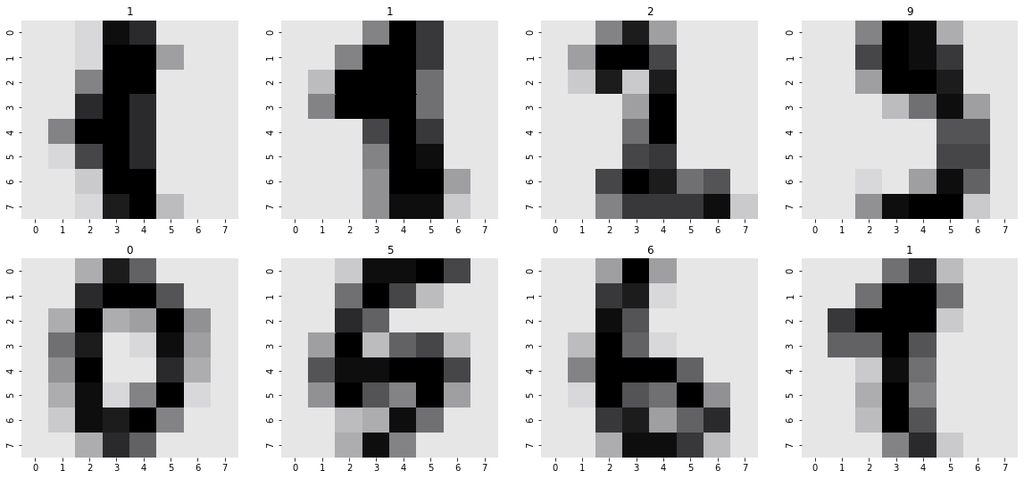

```python
#n_colors = 9
#cMap = plt.cm.get_cmap("bwr", lut=n_colors )
cMap = sns.cubehelix_palette(n_colors=50, hue=0.05, rot=0, light=0.9, dark=0)

l_columns = digits['feature_names']
plt.figure(figsize=(20, 9))

for i in range(8):
    plt.subplot(2, 4, i+1)
    #select images randomly
    idx = np.random.randint(low=0, high=df.shape[0])
    plt.title(int(digits['target'][idx]))
    h_map = sns.heatmap(df[l_columns].iloc[idx].values.reshape(8, 8),
                    vmin=0., vmax=16.,
                    cmap=cMap,
                    cbar=False,
                    #annot=True,
                   )
plt.show()
```

### Boxplots

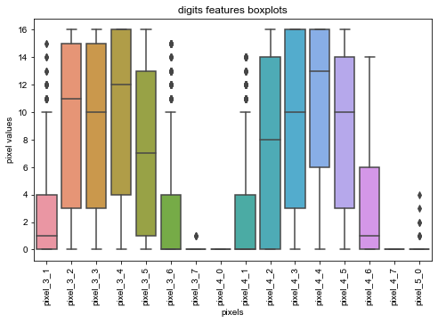

```python
########## feature boxplots
plt.figure( figsize=(8, 5))
plt.title("digits features boxplots")
sns.set_style("white")
bx_plot = sns.boxplot(data=df[df.columns[25:41]])
plt.xticks(rotation=90)
plt.xlabel("pixels")
plt.ylabel("pixel values")
plt.show()
```

### Histograms and scatterplots

Plot histograms of groups of all variables plus target.

We always check scatterplots and correlations, but now their relationship with the 0, 1 target is now less relevant.

### Positive vs Negative Feature Histograms

A clssification problem is more or less solvable depending on the overlap of patterns across classes.

We check this for some features on a simpler two class problem which we define first.

```python
target_digit = 4
new_targets = np.zeros(digits['target'].shape[0])
new_targets[digits['target'] == target_digit] = 1
df['new_target'] = new_targets
```

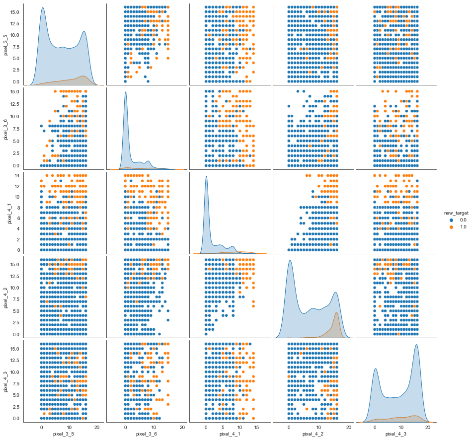

```python
#we choose some features we expect to be meaningful
l_columns = ['pixel_3_5', 'pixel_3_6', 'pixel_4_1', 'pixel_4_2', 'pixel_4_3']
pair_plot = sns.pairplot(df[l_columns + ['new_target']], hue= 'new_target', diag_kind="kde", diag_kws=dict(shade=True))
plt.show()
```

## Correlations

We drop the `target` column.

```python
df[l_columns].corr().round(decimals=3)
```

|  | pixel_3_5 | pixel_3_6 | pixel_4_1 | pixel_4_2 | pixel_4_3 |
| --- | --- | --- | --- | --- | --- |
| pixel_3_5 | 1.000 | 0.512 | 0.081 | -0.007 | -0.257 |
| pixel_3_6 | 0.512 | 1.000 | 0.383 | 0.283 | -0.166 |
| pixel_4_1 | 0.081 | 0.383 | 1.000 | 0.629 | -0.094 |
| pixel_4_2 | -0.007 | 0.283 | 0.629 | 1.000 | 0.332 |
| pixel_4_3 | -0.257 | -0.166 | -0.094 | 0.332 | 1.000 |

Una imagen (o un heatmap) vale más que mil palabras

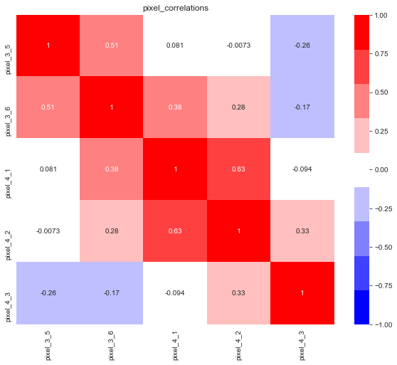

```python
# definir el color map
n_colors = 9
cMap = plt.cm.get_cmap("bwr",lut=n_colors )

# definir el heatmap
plt.figure( figsize=(10, 8))
plt.title('pixel_correlations')
h_map = sns.heatmap(df[l_columns].corr().values,
                    vmin=-1., vmax=1.,
                    cmap=cMap,
                    annot=True,
                    xticklabels=list(df[l_columns]),
                    yticklabels=list(df[l_columns]))
plt.xticks(rotation=90)

# generar el dibujo
plt.show()
```

## Multiclass SVC

We work now with the original targets in a 10-class problem.

```python
x = digits['data']
y = digits['target']

n_folds = 10
skf = StratifiedKFold(n_folds, shuffle=True)

svc = SVC(shrinking=False,
          decision_function_shape='ovr',
          #probability=True,
         )

svc_classifier = Pipeline(steps=[('std_sc', StandardScaler()),
                                 ('svc', svc)])

l_C = [10.**k for k in range(0, 5)]
l_gamma = [2.**k for k in range(-6, -2)]

param_grid = {'svc__C': l_C, 'svc__gamma': l_gamma}

svc_gscv = GridSearchCV(svc_classifier,
                        param_grid=param_grid,
                        cv=skf,
                        #scoring='roc_auc',
                        scoring='accuracy',
                        return_train_score=True,
                        n_jobs=-1,
                        verbose=1)

t_0 = time.time()
#_ = svc_classifier.fit(x, y)
_ = svc_gscv.fit(x, y)
t_1 = time.time()
print("\nmlp_grid_search_time: {0:.2f}m".format((t_1 - t_0)/60.))

# saving alpha_search in a pickle
joblib.dump(svc_gscv, 'svc_gscv.joblib')
```

```
Fitting 10 folds for each of 20 candidates, totalling 200 fits

mlp_grid_search_time: 0.85m
```

```
['svc_gscv.joblib']
```

### Analyzing the CV results

We plot the CV errors with respect to `C` to check on the adequacy of the best hyperparameter.

```python
df_cv_estimator = pd.DataFrame.from_dict(svc_gscv.cv_results_)
df_params = df_cv_estimator[["param_svc__C", "param_svc__gamma", "mean_test_score"]]
display(df_params.sort_values(by="mean_test_score", ascending=False).head())
```

|  | param_svc__C | param_svc__gamma | mean_test_score |
| --- | --- | --- | --- |
| 12 | 1000.0 | 0.015625 | 0.983302 |
| 4 | 10.0 | 0.015625 | 0.983302 |
| 16 | 10000.0 | 0.015625 | 0.983302 |
| 8 | 100.0 | 0.015625 | 0.983302 |
| 17 | 10000.0 | 0.03125 | 0.981077 |

```
best C: 10.000000
C_min: 1.000000	C_max: 10000.000000
best gamma: 0.015625
gamma_min: 0.015625	gamma_max: 0.125000
```

[figure not shown]

```python
svc_gscv = joblib.load('svc_gscv.joblib')

best_C = svc_gscv.best_params_['svc__C']
best_gamma = svc_gscv.best_params_['svc__gamma']

print("best C: %.6f\t" % best_C)
print("C_min: %f\tC_max: %f" % (np.array(l_C).min(), np.array(l_C).max()))

print("best gamma: %.6f\t" % best_gamma)
print("gamma_min: %f\tgamma_max: %f" % (np.array(l_gamma).min(), np.array(l_gamma).max()))

n_colors = 13
cMap = plt.cm.get_cmap("bwr",lut=n_colors )

# definir el heatmap
fig = plt.figure( figsize=(11, 10))
plt.title('SVC C vs gamma')

h_map = sns.heatmap(#df_params.values,
                    df_params['mean_test_score'].values.reshape(len(l_C), -1),
                    cmap=cMap,
                    annot=True,
                    xticklabels=list(l_gamma),
                    yticklabels=list(l_C)
                    )
#plt.xscale('log')
plt.xlabel("C")
#plt.yscale('log')
plt.ylabel("gamma")

#plt.xticks(rotation=90)
plt.show()
```

### Analyzing the performance of the best hyperparameter

And check classifier performance

```python
# refit pipeline with probability=True
best_svc = SVC(C=best_C,
               gamma=best_gamma,
               probability=True,
               shrinking=False,
               decision_function_shape='ovr',
              )

best_svc_pipe = Pipeline(steps=[('std_sc', StandardScaler()),
                                 ('svc', best_svc)])


best_svc_pipe.fit(x, y)
### CV accuracy, recall and precision of best model
prob_pred_svc = cross_val_predict(best_svc_pipe, x, y, method='predict_proba', cv=skf, n_jobs=-1)
y_pred_svc = np.argmax(prob_pred_svc, axis=1)
```

```python
ohc = OneHotEncoder(sparse=False)
y_ohc = ohc.fit_transform(y.reshape(-1, 1))

acc    = accuracy_score(y, y_pred_svc)
recall = recall_score(y, y_pred_svc, average='micro')
prec   = precision_score(y, y_pred_svc, average='micro')
roc_auc = roc_auc_score(y_ohc, prob_pred_svc, multi_class='ovr')

print("acc: %.3f\trecall: %.3f\tprecision: %.3f" % (acc, recall, prec))
print("\nconfusion matrix:\n", confusion_matrix(y, y_pred_svc))
print("auc: %.3f" % (roc_auc))
```

```
acc: 0.983	recall: 0.983	precision: 0.983

confusion matrix:
 [[178   0   0   0   0   0   0   0   0   0]
 [  0 181   0   0   1   0   0   0   0   0]
 [  0   0 174   0   2   0   0   0   1   0]
 [  0   0   0 178   1   1   0   0   2   1]
 [  0   0   0   0 180   0   0   1   0   0]
 [  0   0   0   0   0 177   1   0   1   3]
 [  0   1   0   0   0   0 179   0   1   0]
 [  0   0   1   0   1   0   0 176   0   1]
 [  0   1   1   1   1   0   0   0 170   0]
 [  0   0   0   0   0   1   1   1   3 174]]
auc: 0.999
```

We can also get precision and recall for each class separately.

```python
recall = recall_score(y, y_pred_svc, average=None)
precision = precision_score(y, y_pred_svc, average=None)
print(recall)
print(precision)
```

```
[1.    0.995 0.983 0.973 0.994 0.973 0.989 0.983 0.977 0.967]
[1.    0.989 0.989 0.994 0.968 0.989 0.989 0.989 0.955 0.972]
```

### Predicting probabilities

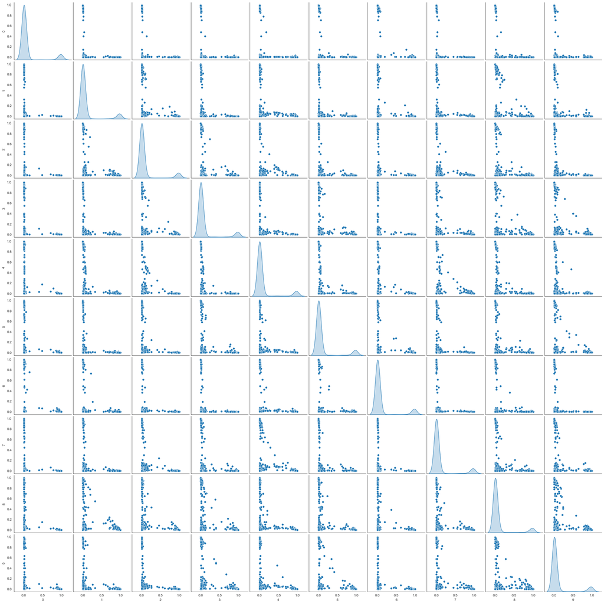

```python
df_pred_prob = pd.DataFrame(data=prob_pred_svc, columns=list(range(10)))
#df_pred_prob['label'] = y_test
pair_plot = sns.pairplot(df_pred_prob, diag_kind="kde", diag_kws=dict(shade=True))
plt.show()
```

## Linear SVC

Although the dimension is not too big, let's try a linear SVC model.

```python
x = digits['data']
y = digits['target']

n_folds = 10
skf = StratifiedKFold(n_folds, shuffle=True)

lsvc = LinearSVC(loss='hinge',
                 multi_class='ovr',
                 fit_intercept=False,
                 tol=1.e-6,
                 max_iter=5000
                )

lsvc_classifier = Pipeline(steps=[('std_sc', StandardScaler()),
                                  ('lsvc', lsvc)])

l_C = [10.**k for k in range(-6, 2)]

param_grid = {'lsvc__C': l_C}

lsvc_gscv = GridSearchCV(lsvc_classifier,
                         param_grid=param_grid,
                         cv=skf,
                         scoring='accuracy',
                         return_train_score=True,
                         n_jobs=-1,
                         verbose=1)

t_0 = time.time()
#_ = svc_classifier.fit(x, y)
_ = lsvc_gscv.fit(x, y)
t_1 = time.time()
print("\nmlp_grid_search_time: {0:.2f}m".format((t_1 - t_0)/60.))

# saving alpha_search in a pickle
joblib.dump(lsvc_gscv, 'lsvc_gscv.joblib')
```

```
Fitting 10 folds for each of 8 candidates, totalling 80 fits

mlp_grid_search_time: 0.62m
```

```
['lsvc_gscv.joblib']
```

### Analyzing the CV results

We plot the CV errors with respect to `C` to check on the adequacy of the best hyperparameter.

```python
df_cv_estimator = pd.DataFrame.from_dict(lsvc_gscv.cv_results_)
df_params = df_cv_estimator[["param_lsvc__C", "mean_test_score"]]
display(df_params.sort_values(by="mean_test_score", ascending=False).head())
```

|  | param_lsvc__C | mean_test_score |
| --- | --- | --- |
| 4 | 0.01 | 0.891477 |
| 3 | 0.001 | 0.885934 |
| 2 | 0.0001 | 0.854770 |
| 0 | 0.000001 | 0.849755 |
| 1 | 0.00001 | 0.849755 |

```
best C: 0.010000
C_min: 0.000001	C_max: 10.000000
```

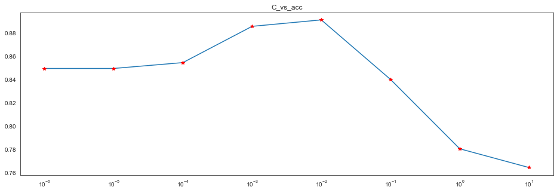

```python
lsvc_gscv = joblib.load('lsvc_gscv.joblib')

best_C = lsvc_gscv.best_params_['lsvc__C']

print("best C: %.6f\t" % best_C)
print("C_min: %f\tC_max: %f" % (np.array(l_C).min(), np.array(l_C).max()))

plt.figure(figsize=(16, 5))
plt.title('C_vs_acc')
plt.xscale('log')
_ = plt.plot( df_cv_estimator['param_lsvc__C'], df_cv_estimator['mean_test_score'], '-',
              df_cv_estimator['param_lsvc__C'], df_cv_estimator['mean_test_score'], '*r')
```

### Analyzing the performance of the best hyperparameter

And check classifier performance

```python
y_pred_lsvc = cross_val_predict(lsvc_gscv.best_estimator_, x, y, cv=skf, n_jobs=-1)
```

```python
ohc = OneHotEncoder(sparse=False)
y_ohc = ohc.fit_transform(y.reshape(-1, 1))

acc    = accuracy_score(y, y_pred_lsvc)
recall = recall_score(y, y_pred_lsvc, average='micro')
prec   = precision_score(y, y_pred_lsvc, average='micro')

print("acc: %.3f\trecall: %.3f\tprecision: %.3f" % (acc, recall, prec))
print("\nconfusion matrix:\n", confusion_matrix(y, y_pred_lsvc))
```

```
acc: 0.890	recall: 0.890	precision: 0.890

confusion matrix:
 [[178   0   0   0   0   0   0   0   0   0]
 [  0 134  26   0   1   1   0   2  13   5]
 [  0   0 161   7   1   1   3   1   3   0]
 [  1   0   4 161   0   3   5   2   4   3]
 [  2   3   0   0 166   0   0   8   1   1]
 [  0   0   0   0   0 172   1   2   0   7]
 [  1   3   0   0   1   2 173   0   0   1]
 [  0   0   0   0   3   2   0 173   1   0]
 [  2   6   1   2   0   4   8   3 137  11]
 [  7   4   2   3   2   5   2   8   3 144]]
```